# Project Python Foundations: FoodHub Data Analysis

Observations on rating

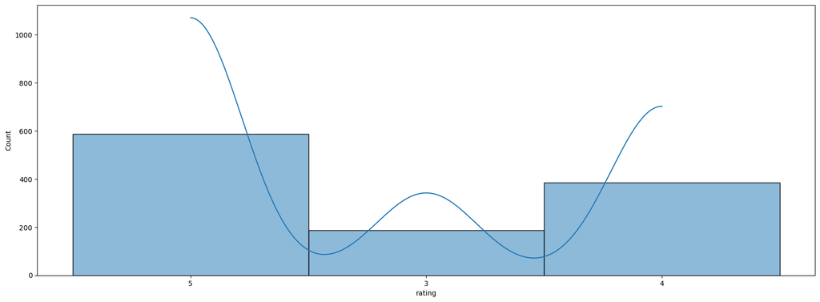

[figure not shown]

```python
plt.figure(figsize=(20, 7))
sns.histplot(data = df, x = 'rating', kde = True )
plt.show()
sns.boxplot(data = df, x = 'rating')
plt.show()
```

*Rating 5 spikes high, showing that it’s the most frequent score—maybe your audience is super satisfied.*

*Rating 3 is the least common, which might mean users are either very happy or just okay—less in-between.*

*The line plot smooths the frequency variation, hinting at possible trends or suggesting how the ratings might behave beyond these three buckets.*

Observation on restaurant name

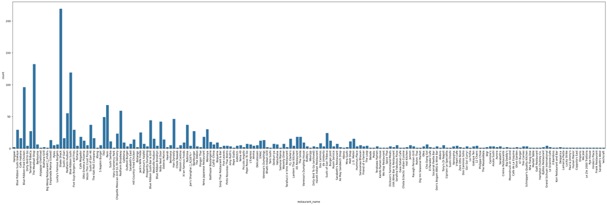

```python
plt.figure(figsize=(40, 10))
sns.countplot(data = df, x = 'restaurant_name')
plt.xticks(rotation = 90)
plt.show()
```

Observation on cuisine type

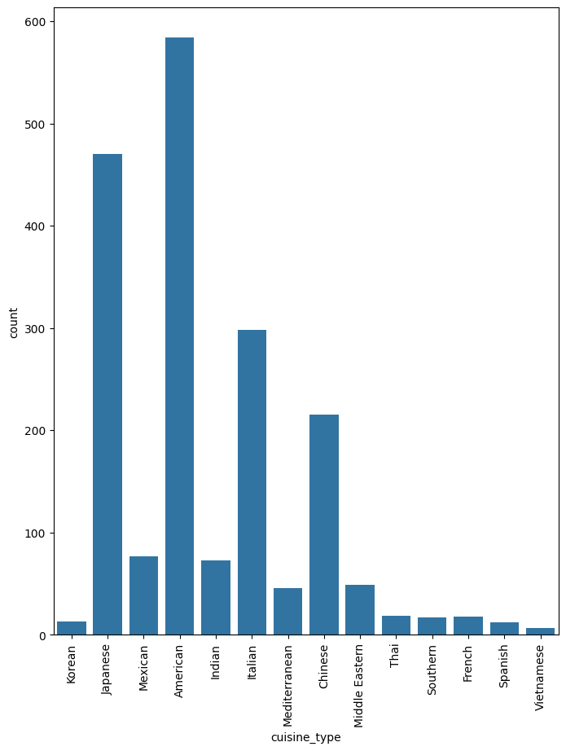

```python
plt.figure(figsize=(8, 10))
sns.countplot(data = df, x = 'cuisine_type')
plt.xticks(rotation = 90)
plt.show()
```

*The distribution is heavily skewed, with a few cuisines dominating and many underrepresented.*

*American cuisine is the most popular, with nearly 600 orders.*

Observation on day of the week

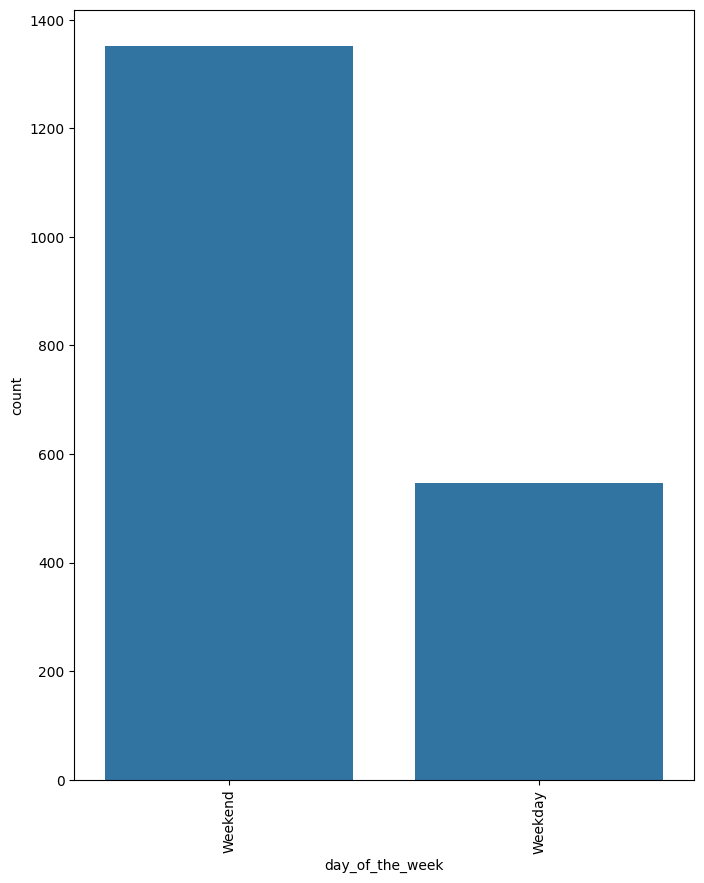

```python
plt.figure(figsize=(8, 10))
sns.countplot(data = df, x = 'day_of_the_week')
plt.xticks(rotation = 90)
plt.show()
```

*Weekend orders are nearly 2.5 times more frequent than Weekday orders.*

Lower order volume during weekdays might be due to: *People cooking at home, Busy work schedules, Possibly fewer promotions or availability*

### **Question 7**: Which are the top 5 restaurants in terms of the number of orders received? [1 mark]

```python
# Write the code here
top_5_restaurants = df.groupby('restaurant_name') \
                      .size() \
                      .sort_values(ascending=False) \
                      .head(5) \
                      .reset_index(name='order_count')
print(top_5_restaurants)
```

```
             restaurant_name  order_count
0                Shake Shack          219
1          The Meatball Shop          132
2          Blue Ribbon Sushi          119
3  Blue Ribbon Fried Chicken           96
4                       Parm           68
```

### **Question 8**: Which is the most popular cuisine on weekends? [1 mark]

```python
# Write the code here
popular_cuisine_weekend = df[df['day_of_the_week'] == 'Weekend'] \
                          .groupby('cuisine_type') \
                          .size() \
                          .sort_values(ascending=False) \
                          .head(1)
print(popular_cuisine_weekend)
```

```
cuisine_type
American    415
dtype: int64
```

### **Question 9**: What percentage of the orders cost more than 20 dollars? [2 marks]

```python
# Write the code here
filtered_df = df[df['cost_of_the_order'] > 20]
percentage = (len(filtered_df) / len(df)) * 100
print(f"Percentage of orders costing more than $20: {percentage:.2f}%")
```

```
Percentage of orders costing more than $20: 29.24%
```

#### Observations:

*Approximately 29.24% of all orders have a cost exceeding $20.*

*This indicates that nearly 3 out of every 10 orders are relatively high-value purchases.*

*The remaining 70.76% of orders are priced $20 or less, suggesting that most customers prefer affordable meals.*

### **Question 10**: What is the mean order delivery time? [1 mark]

```python
# Write the code here
mean_delivery_time = df['delivery_time'].mean()
print(f"Mean order delivery time: {mean_delivery_time:.2f} minutes")
```

```
Mean order delivery time: 24.16 minutes
```

#### Observations:

*The average delivery time across all orders is approximately 24.16 minutes.*

### **Question 11:** The company has decided to give 20% discount vouchers to the top 3 most frequent customers. Find the IDs of these customers and the number of orders they placed. [1 mark]

```python
# Write the code here
top_3_customers = df['customer_id'].value_counts().head(3)
print(top_3_customers)
```

```
52832    13
47440    10
83287     9
Name: customer_id, dtype: int64
```

#### Observations:

*Customer 52832 placed the highest number of orders *13. *Customer 47440 followed with 10 orders, and* *Customer 83287 placed 9 orders.*